# Explore the NOAA Storm Database and answer some basic questions about severe weather events.

Krystle Sawyer

10/11/2021

## Assignment

The basic goal of this assignment is to explore the NOAA Storm Database and answer some basic questions about severe weather events. You must use the database to answer the questions below and show the code for your entire analysis. Your analysis can consist of tables, figures, or other summaries. You may use any R package you want to support your analysis.

### Questions

1. Across the United States, which types of events (as indicated in the EVTYPE variable) are most harmful with respect to population health?
2. Across the United States, which types of events have the greatest economic consequences?

## Synopsis

Based on the data obtained from the NOAA Storm Database tornadoes are identified as the most harmful with respect to population health. The data reflects that tornadoes rank at the top for severe weather events that cause human injuries and fatalities. The weather event that has the greatest economic consequences are floods followed by hurricane/typhoons and then tornadoes. The economic consequences was calculated by aggregating the property and crop damage costs associeted by weather event.

## Data Processing

Setup

Loading the data and processing it to focus on the information needed to answer the assignment.

```r
NOAA<- read.csv("repdata_data_StormData.csv.bz2")

NOAA<- NOAA[, c(8,23:28)]

#converting the decimal in PROPDMG and CROPDMG to reflect the EXP of each associated row more clearly.

NOAA$pd <- 0
NOAA[NOAA$PROPDMGEXP == "H", ]$pd <- NOAA[NOAA$PROPDMGEXP == "H", ]$PROPDMG * 10^2

NOAA[NOAA$PROPDMGEXP == "K", ]$pd <- NOAA[NOAA$PROPDMGEXP == "K", ]$PROPDMG * 10^3

NOAA[NOAA$PROPDMGEXP == "M", ]$pd <- NOAA[NOAA$PROPDMGEXP == "M", ]$PROPDMG * 10^6

NOAA[NOAA$PROPDMGEXP == "B", ]$pd <- NOAA[NOAA$PROPDMGEXP == "B", ]$PROPDMG * 10^9

# Crop Damage
NOAA$cd <- 0
NOAA[NOAA$CROPDMGEXP == "H", ]$cd <- NOAA[NOAA$CROPDMGEXP == "H", ]$CROPDMG * 10^2

NOAA[NOAA$CROPDMGEXP == "K", ]$cd <- NOAA[NOAA$CROPDMGEXP == "K", ]$CROPDMG * 10^3

NOAA[NOAA$CROPDMGEXP == "M", ]$cd <- NOAA[NOAA$CROPDMGEXP == "M", ]$CROPDMG * 10^6

NOAA[NOAA$CROPDMGEXP == "B", ]$cd <- NOAA[NOAA$CROPDMGEXP == "B", ]$CROPDMG * 10^9
```

# Results

## Number of fatalities for each Event Type

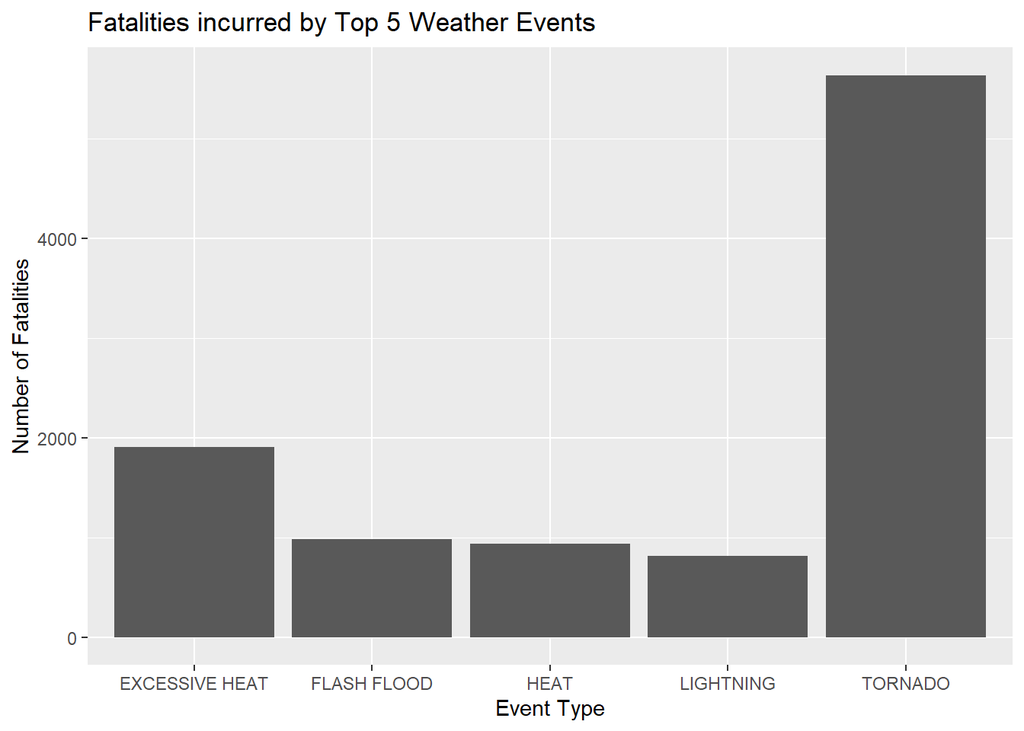

```r
# Sum the number of fatalities by type

fatalities<- aggregate(FATALITIES ~ EVTYPE, data= NOAA, FUN = sum)

# Arrange them by most to least
fatalities<-arrange(fatalities, desc(FATALITIES), EVTYPE)[1:5,]

#plot them in bar chart
eventfatal<- ggplot(fatalities, aes(x= EVTYPE, y=FATALITIES))+ geom_bar(stat="identity")+xlab("Event Type") + ylab("Number of Fatalities") + ggtitle("Fatalities incurred by Top 5 Weather Events")

plot(eventfatal)
```

## Number of injuries for each Event Type

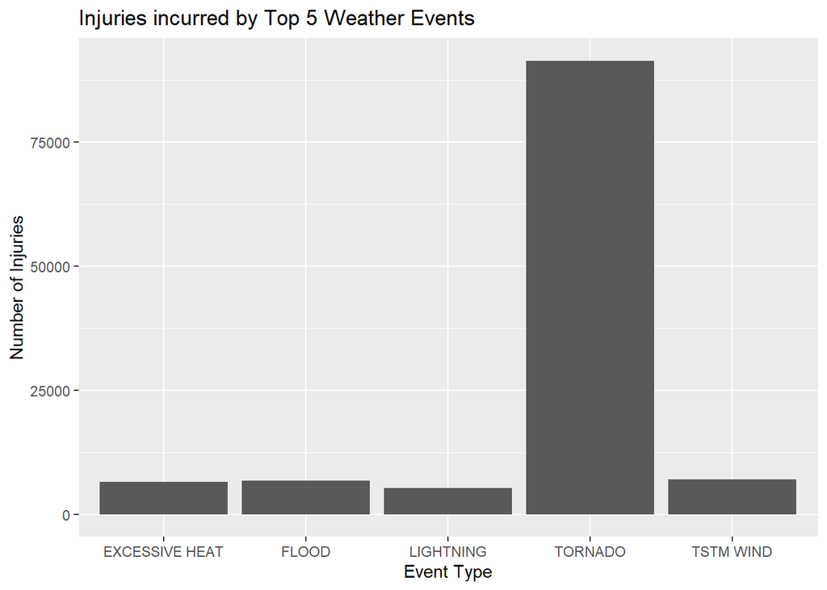

```r
# Sum the number of fatalities by type

injuries<- aggregate(INJURIES ~ EVTYPE, data= NOAA, FUN = sum)

# Arrange them by most to least
injuries<-arrange(injuries, desc(INJURIES), EVTYPE)[1:5,]

#plot them in bar chart
eventinj<- ggplot(injuries, aes(x= EVTYPE, y=INJURIES))+ geom_bar(stat="identity")+ xlab("Event Type") + ylab("Number of Injuries") +
ggtitle("Injuries incurred by Top 5 Weather Events")

plot(eventinj)
```

## Event with greatest economic impact

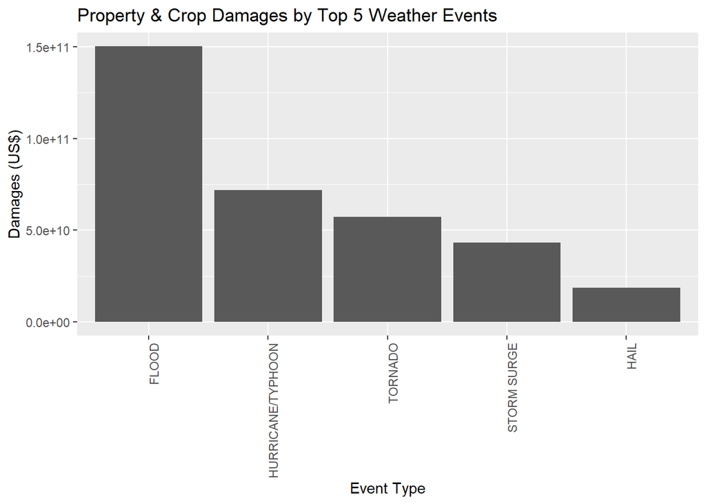

```r
# Sum damage by type

damage<- aggregate( pd+cd ~ EVTYPE, data= NOAA, FUN = sum)

# Arrange them by most to least

names(damage)= c("EVTYPE", "DAMAGECOST")
damage<-arrange(damage, desc(damage$DAMAGECOST), EVTYPE)[1:5,]

damage$EVTYPE <- factor(damage$EVTYPE, levels = damage$EVTYPE)

#plot damage($) in bar chart

ggplot(damage, aes(x = EVTYPE, y = DAMAGECOST)) +
    geom_bar(stat = "identity") +
    theme(axis.text.x = element_text(angle = 90, hjust = 1)) +
    xlab("Event Type") + ylab("Damages (US$)") +
  ggtitle("Property & Crop Damages by Top 5 Weather Events")
```